title: “ML” author: “Sharareh Akbarian” date: “11/03/2021” output: html_document

Approach: Classe, a component variable, is our outcome variable. “Participants were required to execute one series of ten repetitions of the Unilateral Dumbbell Biceps Curl in five separate fashions” for this data set. - exactly according to the specification (Class A) - throwing the elbows to the front (Class B) - lifting the dumbbell only halfway (Class C) - lowering the dumbbell only halfway (Class D) - throwing the hips to the front (Class E)

Decision Tree and Random Forest will be used to compare two versions. Our final model will be the model with the best accuracy.

Our outcome variable “classe” is a factor variable. We split the Training dataset into TrainSet and TestSet datasets.

Cross-validation will be performed by subsampling our training data set randomly without replacement into 2 subsamples: TrainingSet data (75% of the original Training data set) and TestSet data (25%). Our models will be fitted on the TrainSet data, and tested on the TestSet data. The most accurate model would be tested on the original Testing data.

Let’s load packages and data

```r
library(lattice)
library(ggplot2)
library(caret)
library(randomForest)
library(rpart)
library(rpart.plot)
#Loading Data
trainingset <- read.csv("pml-training.csv", na.strings=c("NA","#DIV/0!", ""))
testingset <- read.csv("pml-testing.csv", na.strings=c("NA","#DIV/0!", ""))
```

```r
trainingset<-trainingset[,colSums(is.na(trainingset)) == 0]
testingset <-testingset[,colSums(is.na(testingset)) == 0]
```

# partition the data so that 75% of the training dataset into training and the remaining 25% to testing

```r
traintrainset <- createDataPartition(y=trainingset$classe, p=0.75, list=FALSE)
TrainSet <- trainingset[traintrainset, ]
TestSet <- trainingset[-traintrainset, ]
```

A plot of the “claase” variable to check the frequency of its levels in the TrainTrainingSet data set We can see from the graph that each level frequency is within one order of magnitude of the others. The most common level is A, while the least common is D.

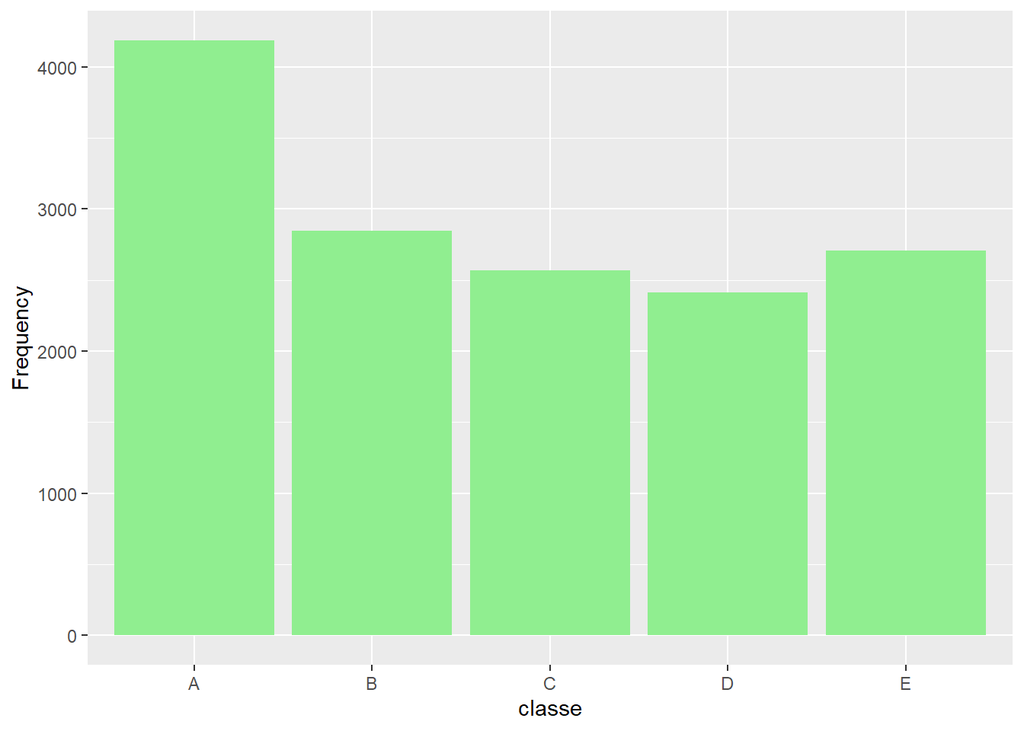

```r
ggplot(data.frame(TrainSet$classe), aes(x=TrainSet$classe)) +
  geom_bar()+
  geom_bar(fill="lightgreen")+
  geom_bar(fill="lightblue",aes(y=..count../sum(..count..)))+
  labs(x = "classe", y = "Frequency")
```

First Prediction Model: Decision Tree

```r
modelDT <- rpart(classe ~ ., data=TrainSet, method="class")

predictionDT <- predict(modelDT, TestSet, type = "class")

confusionMatrix(predictionDT, as.factor(TestSet$classe))
```

```
## Confusion Matrix and Statistics
##
##           Reference
## Prediction    A    B    C    D    E
##          A 1395    1    0    0    0
##          B    0  948    0    0    0
##          C    0    0  855    0    0
##          D    0    0    0  804    0
##          E    0    0    0    0  901
##
## Overall Statistics
##
##                Accuracy : 0.9998
##                  95% CI : (0.9989, 1)
##     No Information Rate : 0.2845
##     P-Value [Acc > NIR] : < 2.2e-16
##
##                   Kappa : 0.9997
##
##  Mcnemar's Test P-Value : NA
##
## Statistics by Class:
##
##                      Class: A Class: B Class: C Class: D Class: E
## Sensitivity            1.0000   0.9989   1.0000   1.0000   1.0000
## Specificity            0.9997   1.0000   1.0000   1.0000   1.0000
## Pos Pred Value         0.9993   1.0000   1.0000   1.0000   1.0000
## Neg Pred Value         1.0000   0.9997   1.0000   1.0000   1.0000
## Prevalence             0.2845   0.1935   0.1743   0.1639   0.1837
## Detection Rate         0.2845   0.1933   0.1743   0.1639   0.1837
## Detection Prevalence   0.2847   0.1933   0.1743   0.1639   0.1837
## Balanced Accuracy      0.9999   0.9995   1.0000   1.0000   1.0000
```

Second Prediction Model: Random Forest

```r
TrainSet$classe = factor (TrainSet$classe)
modelRF <- randomForest(classe ~. , data=TrainSet, method="class")

predictionRF <- predict(modelRF, TestSet, type = "class")

confusionMatrix(predictionRF, as.factor(TestSet$classe))
```

```
## Confusion Matrix and Statistics
##
##           Reference
## Prediction    A    B    C    D    E
##          A 1395    1    0    0    0
##          B    0  948    0    0    0
##          C    0    0  855    0    0
##          D    0    0    0  804    0
##          E    0    0    0    0  901
##
## Overall Statistics
##
##                Accuracy : 0.9998
##                  95% CI : (0.9989, 1)
##     No Information Rate : 0.2845
##     P-Value [Acc > NIR] : < 2.2e-16
##
##                   Kappa : 0.9997
##
##  Mcnemar's Test P-Value : NA
##
## Statistics by Class:
##
##                      Class: A Class: B Class: C Class: D Class: E
## Sensitivity            1.0000   0.9989   1.0000   1.0000   1.0000
## Specificity            0.9997   1.0000   1.0000   1.0000   1.0000
## Pos Pred Value         0.9993   1.0000   1.0000   1.0000   1.0000
## Neg Pred Value         1.0000   0.9997   1.0000   1.0000   1.0000
## Prevalence             0.2845   0.1935   0.1743   0.1639   0.1837
## Detection Rate         0.2845   0.1933   0.1743   0.1639   0.1837
## Detection Prevalence   0.2847   0.1933   0.1743   0.1639   0.1837
## Balanced Accuracy      0.9999   0.9995   1.0000   1.0000   1.0000
```

Conclusion:

```r
FinalModel <- predict(modelRF, testingset, type="class")
FinalModel
```

```
##  1  2  3  4  5  6  7  8  9 10 11 12 13 14 15 16 17 18 19 20
##  A  A  A  A  A  A  A  A  A  A  A  A  A  A  A  A  A  A  A  A
## Levels: A B C D E
```